# Survival and longitudinal data analysis

Comparaison de la prédiction par modèle de survie et par algorithmes de classification

Guedj O. et Marcoux Pépin T.

23/10/2019

# 1. Packages

```r
library(KMsurv)
library(tidyverse)
library(survival)
library(dplyr)
library(survminer)
```

```r
library(ggplot2)
library(tidyverse)
library(ggfortify)
library(caTools)
library(caret)
library(MASS)
library(psych)
library(kableExtra)
library(pROC)
library(e1071)
library(class)
library(randomForest)
```

# 2. Données

Le données étudiées sont issues du jeu de données wpcb: une étude portée sur les cancer du sein de 198 femmes du Winsconsis, USA. Le jeu de données est composé de 198 individus décrits par 35 variables dont: * Une variable d’identification `id`, * Une variable indiquant s’il y a eu rechute du cancer ou non `recurrent`, * Une variable indiquant le temps de rechute `time` (en mois) pour les individus ayant rechuté et indiquant le temps à l’état sain pour les individus n’ayant pas rechuté, * Le reste des variables décrivent la tumeur : sa texture, son périmètre, sa surface…

## 2.1. Importation des données et mise en forme

Dans le dataset, les NA sont représentées par des “?”.

```r
data = read.csv("https://archive.ics.uci.edu/ml/machine-learning-databases/breast-cancer-wisconsin/wpbc.data",
                header=F,
                sep=",",
                na = "?")
```

De plus les variables sont nommées de `var1` à `var35`, il faut donc leur donner des noms plus compréhensibles.

```r
var.names = paste0(rep(c('radius','texture','perimeter','area','smoothness','compactness',
                         'concavity','concave points','symmetry','fractal dimension'),3),
                   c(rep('_mean',10),rep('_SD',10),rep('_worst',10)))
names(data) = c('id','recurrent','time', var.names,c('Tumor size','Lymph node status'))
```

On transforme le type de l’identifiant en factor. Dans la variable `recurrent`, les N par `FALSE` et les R par `TRUE`. On transforme également la variable `time` en numeric.

```r
data = data %>% mutate(id = factor(id)) %>%
                mutate( recurrent = recode_factor(recurrent , "N" = FALSE, 'R' = TRUE ))

data$recurrent = as.logical(data$recurrent)

data = dplyr::mutate(data,time=as.numeric(time))
```

## 2.2. Gestion des valeurs manquantes

```r
na.nbr = NULL
for( i in colnames(data)){
  na.nbr[i] = length(which(is.na(data[,i])))
}
rm(i)
tab.na = cbind(names(data), na.nbr)
kable(tab.na, col.names = c("Variables","Nombre de NA"), row.names = F,
      caption = "Vue d'ensemble des données manqanutes des données wpbc") %>%
  kable_styling(latex_options = "striped", stripe_color = "gray!6")
```

Vue d’ensemble des données manqanutes des données wpbc

| Variables | Nombre de NA |
| --- | --- |
| id | 0 |
| recurrent | 0 |
| time | 0 |
| radius_mean | 0 |
| texture_mean | 0 |
| perimeter_mean | 0 |
| area_mean | 0 |
| smoothness_mean | 0 |
| compactness_mean | 0 |
| concavity_mean | 0 |
| concave points_mean | 0 |
| symmetry_mean | 0 |
| fractal dimension_mean | 0 |
| radius_SD | 0 |
| texture_SD | 0 |
| perimeter_SD | 0 |
| area_SD | 0 |
| smoothness_SD | 0 |
| compactness_SD | 0 |
| concavity_SD | 0 |
| concave points_SD | 0 |
| symmetry_SD | 0 |
| fractal dimension_SD | 0 |
| radius_worst | 0 |
| texture_worst | 0 |
| perimeter_worst | 0 |
| area_worst | 0 |
| smoothness_worst | 0 |
| compactness_worst | 0 |
| concavity_worst | 0 |
| concave points_worst | 0 |
| symmetry_worst | 0 |
| fractal dimension_worst | 0 |
| Tumor size | 0 |
| Lymph node status | 4 |

On fait le choix de remplacer les NA de `Lymph node status` par la médiane de la variable correspondante.

```r
data.no.NA = data %>% replace_na(list(`Lymph node status` = median(data$`Lymph node status`,na.rm =T)))
```

## 2.3. Data Vizualization

### 2.3.1 Fonction de repartition

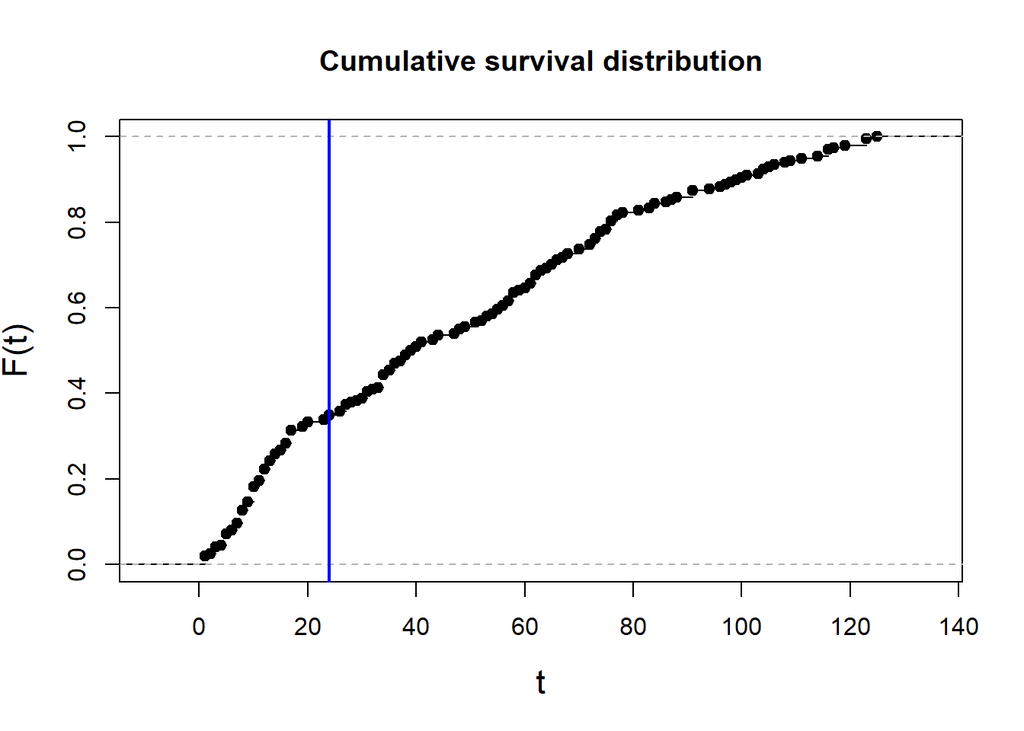

```r
plot(ecdf(data.no.NA$time), main="Cumulative survival distribution",
     xlab="t", ylab="F(t)", cex.lab=1.4)
abline(v = 24, col="blue", lwd=2)
```

### 2.3.2 Rechute

```r
tab.recur = cbind(c("Non","Oui"),table(data.no.NA$recurrent), round(prop.table(table(data.no.NA$recurrent))*100, 2))
kable(tab.recur, col.names = c("Rechute ","n","%"),
      row.names = F,
      caption = "Nombre de rechutes")
```

Nombre de rechutes

| Rechute | n | % |
| --- | --- | --- |
| Non | 151 | 76.26 |
| Oui | 47 | 23.74 |

On remarque la faible proportion de rechutes. C’est un élément auquel il faut préter attention, d’une part lors du split des données et d’autre part pour expliquer une eventuelle difficulté des algorithmes de machine learning à prédire cette rechute.

### 2.3.3 Variables décrivant la tumeur

```r
desc.var.tum = round(describe(data.no.NA[,4:35])[c(1,2,3,4,5,8,9)],2)
kable(desc.var.tum, caption = "Aperçu des variables décrivants la tumeur") %>%
  kable_styling(latex_options = "striped", stripe_color = "gray!6")
```

Aperçu des variables décrivants la tumeur

|  | vars | n | mean | sd | median | min | max |
| --- | --- | --- | --- | --- | --- | --- | --- |
| radius_mean | 1 | 198 | 17.41 | 3.16 | 17.29 | 10.95 | 27.22 |
| texture_mean | 2 | 198 | 22.28 | 4.30 | 21.75 | 10.38 | 39.28 |
| perimeter_mean | 3 | 198 | 114.86 | 21.38 | 113.70 | 71.90 | 182.10 |
| area_mean | 4 | 198 | 970.04 | 352.15 | 929.10 | 361.60 | 2250.00 |
| smoothness_mean | 5 | 198 | 0.10 | 0.01 | 0.10 | 0.07 | 0.14 |
| compactness_mean | 6 | 198 | 0.14 | 0.05 | 0.13 | 0.05 | 0.31 |
| concavity_mean | 7 | 198 | 0.16 | 0.07 | 0.15 | 0.02 | 0.43 |
| concave points_mean | 8 | 198 | 0.09 | 0.03 | 0.09 | 0.02 | 0.20 |
| symmetry_mean | 9 | 198 | 0.19 | 0.03 | 0.19 | 0.13 | 0.30 |
| fractal dimension_mean | 10 | 198 | 0.06 | 0.01 | 0.06 | 0.05 | 0.10 |
| radius_SD | 11 | 198 | 0.60 | 0.31 | 0.53 | 0.19 | 1.82 |
| texture_SD | 12 | 198 | 1.26 | 0.53 | 1.17 | 0.36 | 3.50 |
| perimeter_SD | 13 | 198 | 4.26 | 2.19 | 3.77 | 1.15 | 13.28 |
| area_SD | 14 | 198 | 70.23 | 47.98 | 58.45 | 13.99 | 316.00 |
| smoothness_SD | 15 | 198 | 0.01 | 0.00 | 0.01 | 0.00 | 0.03 |
| compactness_SD | 16 | 198 | 0.03 | 0.02 | 0.03 | 0.01 | 0.14 |
| concavity_SD | 17 | 198 | 0.04 | 0.02 | 0.04 | 0.01 | 0.14 |
| concave points_SD | 18 | 198 | 0.02 | 0.01 | 0.01 | 0.01 | 0.04 |
| symmetry_SD | 19 | 198 | 0.02 | 0.01 | 0.02 | 0.01 | 0.06 |
| fractal dimension_SD | 20 | 198 | 0.00 | 0.00 | 0.00 | 0.00 | 0.01 |
| radius_worst | 21 | 198 | 21.02 | 4.24 | 20.52 | 12.84 | 35.13 |
| texture_worst | 22 | 198 | 30.14 | 6.02 | 30.13 | 16.67 | 49.54 |
| perimeter_worst | 23 | 198 | 140.35 | 28.89 | 136.50 | 85.10 | 232.20 |
| area_worst | 24 | 198 | 1404.96 | 586.01 | 1295.00 | 508.10 | 3903.00 |
| smoothness_worst | 25 | 198 | 0.14 | 0.02 | 0.14 | 0.08 | 0.22 |
| compactness_worst | 26 | 198 | 0.37 | 0.16 | 0.35 | 0.05 | 1.06 |
| concavity_worst | 27 | 198 | 0.44 | 0.17 | 0.40 | 0.02 | 1.17 |
| concave points_worst | 28 | 198 | 0.18 | 0.05 | 0.18 | 0.03 | 0.29 |
| symmetry_worst | 29 | 198 | 0.32 | 0.08 | 0.31 | 0.16 | 0.66 |
| fractal dimension_worst | 30 | 198 | 0.09 | 0.02 | 0.09 | 0.06 | 0.21 |
| Tumor size | 31 | 198 | 2.85 | 1.94 | 2.50 | 0.40 | 10.00 |
| Lymph node status | 32 | 198 | 3.17 | 5.43 | 1.00 | 0.00 | 27.00 |

## 2.4. Scaling

Pour pouvoir comparer les varaibles entre elles on les normalise en centrant et réduisant les données (sauf les 3 premières variables: `id`, `recurrent` et `time`).

```r
scale = function(x){
  (x- mean(x,na.rm=T)) / sd(x,na.rm=T)
}

data.scaled =  data.no.NA %>% mutate_at(names(data)[-c(1,2,3)], scale)
```

## 2.5. Variable de censure

On note `Z` la variable de censure. Trois cas sont possibles:

```r
data.scaled = data.scaled %>%
  mutate(Z = ifelse( (time <= 24) & (recurrent == T),1,
                  ifelse( (time > 24) & (recurrent == T),0,
                         ifelse( (time > 24) & (recurrent == F),0,NA)
                         )
                  )
         )
data.scaled$Z = as.factor(data.scaled$Z)

kable(table(data.scaled$Z, useNA = "always"),
      caption = "Variable de censure",
      col.names = c("z","n"))
```

Variable de censure

| z | n |
| --- | --- |
| 0 | 129 |
| 1 | 29 |
| NA | 40 |

## 2.6. Split des données

On ajoute à data.scaled une variable d’indices: chiffres de 1 à 198. Puis on utilise la fonction `createDataPartition` pour attribuer $80 \%$ des données au train et les stocker dans une matrice (list = FALSE).

```r
set.seed(42) #Create simulated values that are reproductible.
data.scaled = data.scaled %>% mutate(id_1n = c(1:nrow(data.scaled)))
trainIndex = createDataPartition(data.scaled$recurrent, p = 0.8, list = FALSE, times = 1)
train = data.scaled %>% filter(id_1n %in% trainIndex)
test = data.scaled[-which(data.scaled$id_1n %in% train$id_1n),]
```

On peut vérifier graphiquement la bonne stratification des données:

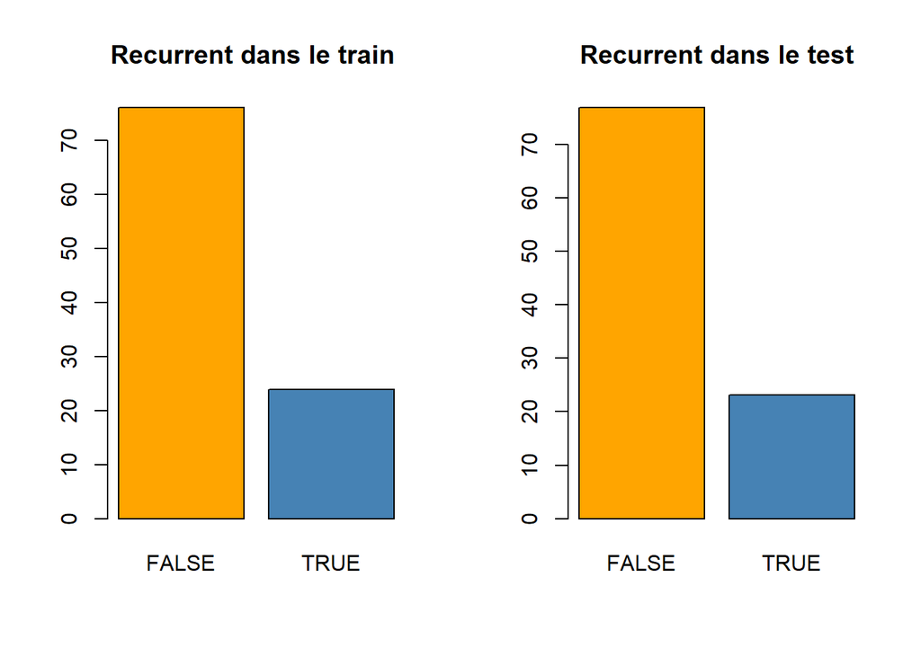

```r
par(mfrow = c(1,2))
barplot(prop.table(table(train$recurrent))*100, col = c("orange","steelblue"),
        main = "Recurrent dans le train ")
barplot(prop.table(table(test$recurrent))*100, col = c("orange","steelblue"),
        main = "Recurrent dans le test")
```

Enfin, on crée une autre partition des données en train et en test ($80 \% ~/~20\%$) sans la variable de censure:

```r
train.surv = train %>% dplyr::select(-Z)
test.surv = test %>% dplyr::select(-Z)
```

# 3. Modèles de Survie

## 3.1 Kaplan Meier global

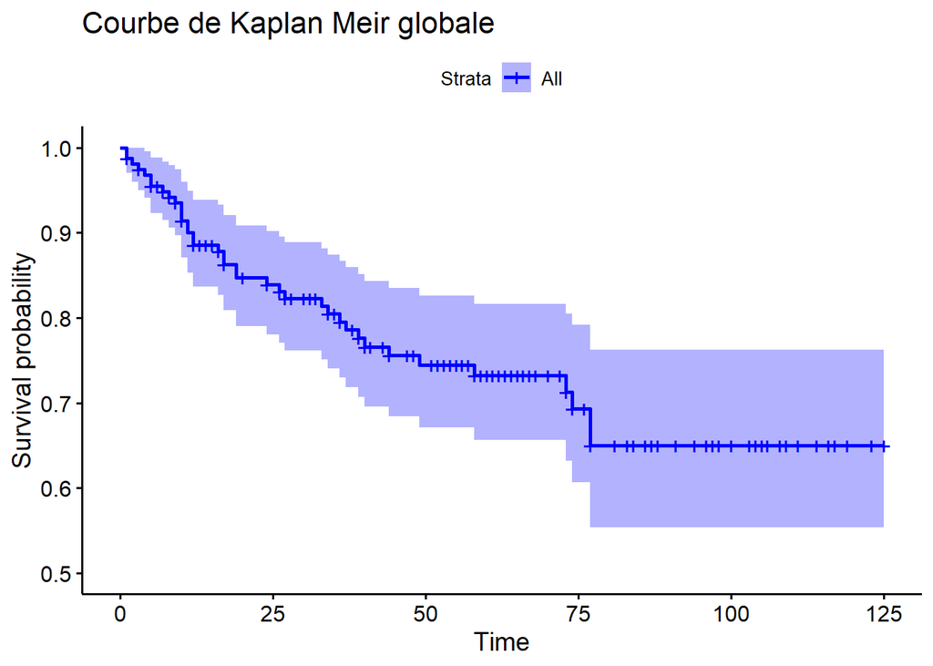

```r
km.global = survfit(Surv(time, recurrent) ~ 1, data = train.surv)
ggsurvplot(km.global, ylim = c(0.5,1), palette = "blue") + ggtitle("Courbe de Kaplan Meir globale")
```

## 3.2 Modèle de Cox full

### 3.2.1 Modèle

On commence par un modèle full (sans les deux variables d’identification):

```r
cox.all = coxph(Surv(time,recurrent)~.-id -id_1n ,data = train.surv)

df.cox.all = data.frame(format(summary(cox.all)$conf.int[,1],scientific = T, digit = 2),
                        paste("[",format(summary(cox.all)$conf.int[,3], scientific = T, digit = 2),
                              ";",format(summary(cox.all)$conf.int[,4],scientific = T, digit = 2),"]"),
                        format(summary(cox.all)$coefficient[,5], scientific = T, digit = 2),
                        ifelse(summary(cox.all)$coefficient[,5] <= 0.05, "*","")
)

colnames(df.cox.all) = c("exp(coef)", "IC", "p", "Significativité ")
kable(df.cox.all, caption = "Modèle de cox avec toutes les covariables") %>%
  kable_styling(latex_options = "striped", stripe_color = "gray!6")
```

Modèle de cox avec toutes les covariables

exp(coef)

IC

p

Significativité

radius_mean

6.1e-08

[ 4.0e-16 ; 9.2e+00 ]

8.4e-02

texture_mean

4.7e-01

[ 1.1e-01 ; 2.0e+00 ]

3.1e-01

perimeter_mean

1.2e+06

[ 8.5e-03 ; 1.7e+14 ]

1.4e-01

area_mean

5.8e+01

[ 1.5e-01 ; 2.3e+04 ]

1.8e-01

smoothness_mean

4.1e+00

[ 9.8e-01 ; 1.7e+01 ]

5.3e-02

compactness_mean

4.2e+00

[ 1.6e-01 ; 1.1e+02 ]

3.9e-01

concavity_mean

1.7e-01

[ 1.1e-02 ; 2.6e+00 ]

2.0e-01

`concave points_mean`

5.9e-01

[ 6.2e-02 ; 5.5e+00 ]

6.4e-01

symmetry_mean

5.1e-01

[ 1.9e-01 ; 1.4e+00 ]

1.8e-01

`fractal dimension_mean`

8.9e-02

[ 1.1e-02 ; 7.1e-01 ]

2.3e-02

radius_SD

4.3e-01

[ 3.8e-03 ; 4.9e+01 ]

7.3e-01

texture_SD

3.4e-01

[ 8.8e-02 ; 1.3e+00 ]

1.1e-01

perimeter_SD

7.0e+00

[ 7.6e-02 ; 6.5e+02 ]

4.0e-01

area_SD

9.5e-01

[ 5.7e-02 ; 1.6e+01 ]

9.7e-01

smoothness_SD

1.0e+00

[ 2.9e-01 ; 3.8e+00 ]

9.5e-01

compactness_SD

1.0e+01

[ 1.1e+00 ; 1.0e+02 ]

4.5e-02

concavity_SD

1.9e-01

[ 2.0e-02 ; 1.8e+00 ]

1.5e-01

`concave points_SD`

1.2e+00

[ 3.0e-01 ; 4.6e+00 ]

8.2e-01

symmetry_SD

8.9e-01

[ 2.7e-01 ; 2.9e+00 ]

8.5e-01

`fractal dimension_SD`

8.4e-01

[ 1.4e-01 ; 5.1e+00 ]

8.5e-01

radius_worst

5.9e+01

[ 6.8e-03 ; 5.1e+05 ]

3.8e-01

texture_worst

2.2e+00

[ 3.4e-01 ; 1.5e+01 ]

4.0e-01

perimeter_worst

9.2e-02

[ 1.2e-04 ; 7.2e+01 ]

4.8e-01

area_worst

8.3e-02

[ 1.4e-04 ; 5.0e+01 ]

4.5e-01

smoothness_worst

1.8e+00

[ 5.5e-01 ; 6.0e+00 ]

3.2e-01

compactness_worst

3.7e-02

[ 2.5e-03 ; 5.5e-01 ]

1.6e-02

concavity_worst

6.8e+00

[ 6.9e-01 ; 6.8e+01 ]

1.0e-01

`concave points_worst`

7.1e-01

[ 1.8e-01 ; 2.8e+00 ]

6.3e-01

symmetry_worst

1.5e+00

[ 3.2e-01 ; 7.2e+00 ]

6.1e-01

`fractal dimension_worst`

3.4e+00

[ 3.1e-01 ; 3.8e+01 ]

3.1e-01

`Tumor size`

9.1e-01

[ 6.0e-01 ; 1.4e+00 ]

6.5e-01

`Lymph node status`

1.6e+00

[ 1.1e+00 ; 2.4e+00 ]

1.0e-02

On remarque que trés peu de variables sont significatives.

```r
cat("La probabilité de ne pas rechuter à 24 mois est de",
    round(unlist(summary(km.global, time = 24))$surv, 2),"avec un IC de [",
    round(unlist(summary(km.global, time = 24))$lower,2),";" ,
    round(unlist(summary(km.global, time = 24))$upper, 2), "]")
```

```
## La probabilité de ne pas rechuter à 24 mois est de 0.84 avec un IC de [ 0.78 ; 0.9 ]
```

### 3.2.2 Prédiction, ROC et AUC

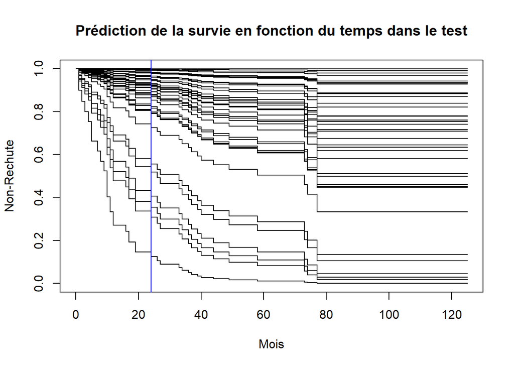

```r
plot(survfit(cox.all , newdata = test.surv), xlab = "Mois", ylab="Non-Rechute", main = "Prédiction de la survie en fonction du temps dans le test")
abline(v = 24, col = "blue")
```

```r
pred.cox.all = survfit(cox.all , newdata = test.surv)
prob.pred.24.all = pred.cox.all$surv[24,]
```

prob.pred.24 contient les predictions de survie à 24 mois des individus du test.

Une proba élévée indique une grande chance de survie donc une faible chance de faire une rechute de cancer.

En fixant un treshold à 0.5 on peut ainsi dire: si un individu a une propabilité de survie plus petite que 0.5 alors il a une “grande” chance de rechuter donc on attribue la valeur 1 à la variable de rechute predite et 0 sinon:

```r
pred.24.all = ifelse(prob.pred.24.all <= 0.5, 1, 0)
pred.24.all = as.factor(pred.24.all)
```

On obtient alors la matrice de confusion suivante :

```r
kable(table(Predicted = pred.24.all,Real = test.surv$recurrent), caption = "Matrice de confusion pour la prédiction dans le modele cox.all", col.names = c("Real.0","Real.1"))
```

Matrice de confusion pour la prédiction dans le modele cox.all

|  | Real.0 | Real.1 |
| --- | --- | --- |
| 0 | 26 | 8 |
| 1 | 4 | 1 |

Le modèle a du mal à prédire correctement les rechute. Cela est peut-être du au faible nombre de rechutes dans le dataset par rapport à celui de non-rehutes.

En faisant varier le treshold entre 0 et 1 on obtient la courbe ROC suivante:

```r
roc.cox.all = roc(response = test.surv$recurrent, predictor = prob.pred.24.all)
```

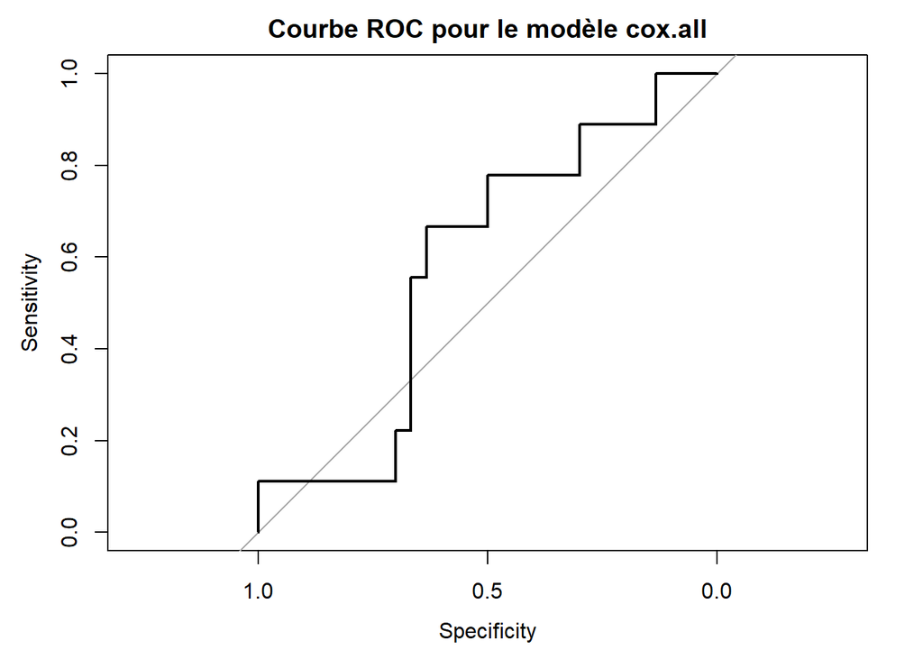

```r
plot(roc.cox.all, main = "Courbe ROC pour le modèle cox.all")
```

```r
auc.cox.all = auc(roc.cox.all)
cat("L'AUC du modèle cox.all est de:",auc.cox.all)
```

```
## L'AUC du modèle cox.all est de: 0.5851852
```

Si l’on fixe le seuil à l’une des valeur prise par lacourbe ROC on peut calculer une accuracy du modèle (afin de pour le comparer aux modèles dont ont ne peut pas tracer la courbe ROC).

Etant donné qu’il est trés important de bien classifier les individus qui vont effectivement faire une rechute à 24 mois, on choisi un treshold “bas”

```r
pred.24.all.bis = ifelse(prob.pred.24.all <= 0.5, 1, 0)
pred.24.all.bis = as.factor(pred.24.all.bis)
table(Pred = pred.24.all.bis, real = test.surv$recurrent)
```

```
##     real
## Pred FALSE TRUE
##    0    26    8
##    1     4    1
```

On a donc:

```r
acc.cox.all = (26 +1) /39
acc.cox.all
```

```
## [1] 0.6923077
```

### 3.2.3 Diagnostique du modèle

Le modèle de Cox a une hypothèse importante: la proportionnalité des risques relatifs (equivalente à la non dépendance en temps des résidus de shonfeld).

Pour la vérifier on peut: * Faire un test * Regarer l’allure des résidus

```r
test.hyp.cox.all <- cox.zph(cox.all)
kable(format(as.matrix(test.hyp.cox.all$table), scientific = T, digit = 2)) %>%
  kable_styling(latex_options = "striped", stripe_color = "gray!6")
```

|  | rho | chisq | p |
| --- | --- | --- | --- |
| radius_mean | -2.9e-01 | 5.4e+00 | 2.0e-02 |
| texture_mean | -1.2e-01 | 5.5e-01 | 4.6e-01 |
| perimeter_mean | 2.5e-01 | 4.3e+00 | 3.9e-02 |
| area_mean | 2.8e-01 | 2.9e+00 | 9.0e-02 |
| smoothness_mean | 1.7e-01 | 1.5e+00 | 2.2e-01 |
| compactness_mean | -2.8e-01 | 7.4e+00 | 6.6e-03 |
| concavity_mean | -5.3e-02 | 1.1e-01 | 7.4e-01 |
| `concave points_mean` | -1.8e-01 | 9.9e-01 | 3.2e-01 |
| symmetry_mean | 4.3e-01 | 1.0e+01 | 1.3e-03 |
| `fractal dimension_mean` | 1.6e-01 | 1.5e+00 | 2.1e-01 |
| radius_SD | 1.1e-01 | 5.4e-01 | 4.6e-01 |
| texture_SD | -1.1e-02 | 6.6e-03 | 9.4e-01 |
| perimeter_SD | 5.4e-03 | 1.3e-03 | 9.7e-01 |
| area_SD | -2.1e-01 | 1.8e+00 | 1.9e-01 |
| smoothness_SD | 1.3e-01 | 5.0e-01 | 4.8e-01 |
| compactness_SD | 2.9e-02 | 4.1e-02 | 8.4e-01 |
| concavity_SD | -1.1e-01 | 5.3e-01 | 4.7e-01 |
| `concave points_SD` | -3.9e-02 | 3.3e-02 | 8.6e-01 |
| symmetry_SD | 9.3e-02 | 2.5e-01 | 6.1e-01 |
| `fractal dimension_SD` | 5.5e-02 | 1.4e-01 | 7.1e-01 |
| radius_worst | -5.2e-02 | 1.6e-01 | 6.9e-01 |
| texture_worst | 1.1e-01 | 5.1e-01 | 4.7e-01 |
| perimeter_worst | 3.7e-02 | 1.1e-01 | 7.5e-01 |
| area_worst | 2.1e-02 | 1.7e-02 | 9.0e-01 |
| smoothness_worst | -3.6e-02 | 7.3e-02 | 7.9e-01 |
| compactness_worst | 1.7e-01 | 1.8e+00 | 1.9e-01 |
| concavity_worst | 9.6e-02 | 4.2e-01 | 5.2e-01 |
| `concave points_worst` | -1.3e-01 | 6.8e-01 | 4.1e-01 |
| symmetry_worst | -2.1e-01 | 1.6e+00 | 2.0e-01 |
| `fractal dimension_worst` | -1.1e-01 | 4.6e-01 | 5.0e-01 |
| `Tumor size` | 8.7e-02 | 3.3e-01 | 5.6e-01 |
| `Lymph node status` | -2.0e-03 | 2.1e-04 | 9.9e-01 |
| GLOBAL | NA | 4.0e+01 | 1.5e-01 |

[figure not shown]

```r
par(mfrow = c(4,3))
ggcoxzph(test.hyp.cox.all)
```

## 3.3 Step AIC

### 3.3.1 Cox model

On effectue alors une sélection de variables basée sur le critère AIC:

```r
cox.AIC = stepAIC(cox.all,trace=F)
df.cox.AIC = data.frame(format(summary(cox.AIC)$conf.int[,1],scientific = T, digit = 2),
                        paste("[",format(summary(cox.AIC)$conf.int[,3], scientific = T, digit = 2),
                              ";",format(summary(cox.AIC)$conf.int[,4],scientific = T, digit = 2),"]"),
                        format(summary(cox.AIC)$coefficient[,5], scientific = T, digit = 2),
                        ifelse(summary(cox.AIC)$coefficient[,5] <= 0.05, "*","")
)

colnames(df.cox.AIC) = c("exp(coef)", "IC", "p", "Significativité ")
kable(df.cox.AIC, caption = "Modèle de cox avec toutes les covariables") %>%
  kable_styling(latex_options = "striped", stripe_color = "gray!6")
```

exp(coef)

IC

p

Significativité

radius_mean

4.9e-07

[ 9.1e-11 ; 2.6e-03 ]

9.1e-04

perimeter_mean

5.2e+06

[ 5.9e+02 ; 4.6e+10 ]

8.4e-04

smoothness_mean

4.5e+00

[ 1.7e+00 ; 1.2e+01 ]

2.3e-03

concavity_mean

1.0e-01

[ 1.6e-02 ; 6.3e-01 ]

1.4e-02

`fractal dimension_mean`

2.5e-01

[ 1.0e-01 ; 6.0e-01 ]

2.1e-03

texture_SD

5.6e-01

[ 3.2e-01 ; 9.7e-01 ]

4.0e-02

perimeter_SD

1.7e+00

[ 1.0e+00 ; 2.8e+00 ]

3.7e-02

compactness_SD

3.9e+00

[ 1.3e+00 ; 1.2e+01 ]

1.6e-02

concavity_SD

3.1e-01

[ 1.0e-01 ; 9.3e-01 ]

3.6e-02

compactness_worst

2.1e-01

[ 6.3e-02 ; 6.8e-01 ]

9.8e-03

concavity_worst

7.1e+00

[ 2.0e+00 ; 2.5e+01 ]

2.3e-03

`Lymph node status`

1.5e+00

[ 1.1e+00 ; 2.0e+00 ]

5.7e-03

Le modèle retenu a 12 variables.

### 3.3.2 Prediction, ROC et AUC

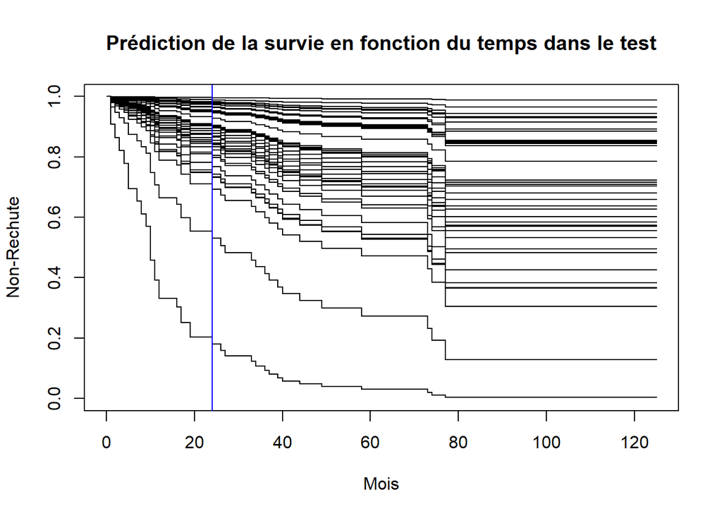

```r
plot(survfit(cox.AIC , newdata = test.surv), xlab = "Mois", ylab="Non-Rechute", main = "Prédiction de la survie en fonction du temps dans le test")
abline(v = 24, col = "blue")
```

```r
pred.cox.AIC = survfit(cox.AIC , newdata = test.surv)
prob.pred.24.AIC = pred.cox.AIC$surv[24,]
```

prob.pred.24 contient les predictions de survie à 24 mois des individus du test.

Une proba élévée indique une grande chance de survie donc une faible chance de faire une rechute de cancer.

En fixant un treshold à 0.5 on peut ainsi dire: si un individu a une propabilité de survie plus petite que 0.5 alors il a une “grande” chance de rechuter donc on attribue la valeur 1 à la variable de rechute predite et 0 sinon:

```r
pred.24.AIC = ifelse(prob.pred.24.AIC <= 0.5, 1, 0)
pred.24.AIC = as.factor(pred.24.AIC)
```

On obtient alors la matrice de confusion suivante :

```r
kable(table(Predicted = pred.24.AIC, Real = test.surv$recurrent),
      caption = "Matrice de confusion pour la prédiction dans le modele cox.AIC",
      col.names = c("Real.0","Real.1"))
```

Matrice de confusion pour la prédiction dans le modele cox.AIC

|  | Real.0 | Real.1 |
| --- | --- | --- |
| 0 | 29 | 8 |
| 1 | 1 | 1 |

Le modèle a du mal à prédire correctement les rechute. Cela est peut-être du au faible nombre de rechutes dans le dataset par rapport à celui de non-rechutes.

En faisant varier le treshold entre 0 et 1 on obtient la courbe ROC suivante:

```r
roc.cox.AIC = roc(response = test.surv$recurrent, predictor = prob.pred.24.AIC)
```

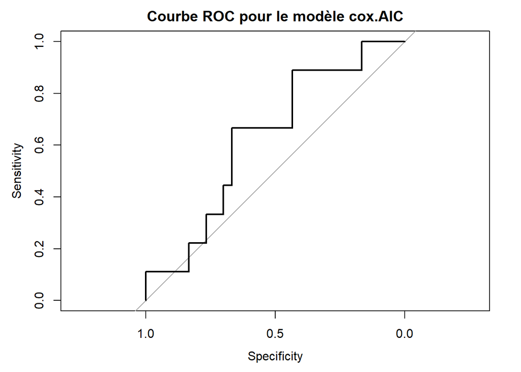

```r
plot(roc.cox.AIC, main = "Courbe ROC pour le modèle cox.AIC")
```

```r
auc.cox.AIC = auc(roc.cox.AIC)
cat("L'AUC du modèle cox.AIC est de:",auc.cox.AIC)
```

```
## L'AUC du modèle cox.AIC est de: 0.6296296
```

De même que precedement, on fixe un treshold à 0.5 et on calcule l’accuracy du cox.AIC:

```r
pred.24.AIC.bis = ifelse(prob.pred.24.AIC <= 0.5, 1, 0)
pred.24.AIC.bis = as.factor(pred.24.AIC.bis)
table(Pred = pred.24.AIC.bis, real = test.surv$recurrent)
```

```
##     real
## Pred FALSE TRUE
##    0    29    8
##    1     1    1
```

On a donc:

```r
acc.cox.AIC = (29 + 1) /39
acc.cox.AIC
```

```
## [1] 0.7692308
```

### 3.3.3 Diagnostique du modèle

```r
test.hyp.cox.AIC <- cox.zph(cox.AIC)
kable(format(as.matrix(test.hyp.cox.AIC$table), scientific = T, digit = 2)) %>%
  kable_styling(latex_options = "striped", stripe_color = "gray!6")
```

|  | rho | chisq | p |
| --- | --- | --- | --- |
| radius_mean | -7.8e-02 | 1.9e-01 | 6.6e-01 |
| perimeter_mean | 7.2e-02 | 1.8e-01 | 6.8e-01 |
| smoothness_mean | 7.7e-02 | 2.7e-01 | 6.1e-01 |
| concavity_mean | -1.4e-01 | 7.8e-01 | 3.8e-01 |
| `fractal dimension_mean` | -2.3e-02 | 2.0e-02 | 8.9e-01 |
| texture_SD | 2.2e-01 | 2.0e+00 | 1.6e-01 |
| perimeter_SD | 7.3e-02 | 2.2e-01 | 6.4e-01 |
| compactness_SD | 4.0e-02 | 6.7e-02 | 8.0e-01 |
| concavity_SD | 3.9e-02 | 6.4e-02 | 8.0e-01 |
| compactness_worst | -2.0e-02 | 1.5e-02 | 9.0e-01 |
| concavity_worst | 1.1e-01 | 4.3e-01 | 5.1e-01 |
| `Lymph node status` | 1.1e-01 | 4.0e-01 | 5.3e-01 |
| GLOBAL | NA | 1.1e+01 | 5.7e-01 |

Aucune des p.valeur n’est inferieure à 0.05. Etanr donné que l’hypothèse nulle de ce test est la non-dependance en temps des résidus de schonfeld et compte tenu des p.valeur obtenues on peut conclure à la vérification de l’hypothèse de proportionnalité des risques relatifs (c’est à dire on ne rejette pas $H_0$).

[figure not shown]

```r
par(mfrow = c(4,3))
ggcoxzph(test.hyp.cox.AIC)
```

# 4. Classification

Afin de comparer les résultats des modèles de classification avec ceux du modèle `cox.AIC` et `cox.all`, pour chaque classifier nous feraont deux prédition: l’une en se basant sur les varaibles du moèele full et l’autre sur les varaible du modèle AIC.

## 4.1 Création du train et du test

### 4.1.1 Avec toutes les variables

```r
var.all = c( "recurrent","radius_mean","texture_mean","perimeter_mean","area_mean",
             "smoothness_mean","compactness_mean" ,"concavity_mean",
             "concave points_mean","symmetry_mean", "fractal dimension_mean",
             "radius_SD","texture_SD","perimeter_SD","area_SD"            ,"smoothness_SD"          ,   "compactness_SD"
 ,"concavity_SD"           ,   "concave points_SD"
 ,"symmetry_SD"            ,   "fractal dimension_SD"
 ,"radius_worst"           ,   "texture_worst"
 ,"perimeter_worst"        ,   "area_worst"
 ,"smoothness_worst"       ,   "compactness_worst"
 ,"concavity_worst"        ,   "concave points_worst"
 ,"symmetry_worst"         ,   "fractal dimension_worst"
 ,"Tumor size"           ,   "Lymph node status"    )

train.clf.all = train[, var.all]
test.clf.all = test[, var.all]
```

### 4.1.2 Avec les variables issues de l’AIC

```r
var.AIC = c("recurrent", "radius_mean", "perimeter_mean", "smoothness_mean", "concavity_mean", "fractal dimension_mean",
    "texture_SD", "perimeter_SD", "compactness_SD", "concavity_SD", "compactness_worst", "concavity_worst", "Lymph node status")
train.clf.AIC = train[, var.AIC]
test.clf.AIC = test[, var.AIC]
```

## 4.2 Prédictions, ROC, AUC et Accuracy sur les variables issues de l’AIC

### 4.2.1 Naives Bayes

```r
mod.NB.AIC = naiveBayes(recurrent ~ ., data = train.clf.AIC)
pred.NB.AIC = predict(mod.NB.AIC, subset(test.clf.AIC, select = -recurrent))
cm.NB.AIC = confusionMatrix(as.factor(pred.NB.AIC), as.factor(test.clf.AIC$recurrent))
cm.NB.AIC$table
```

```
##           Reference
## Prediction FALSE TRUE
##      FALSE    28    7
##      TRUE      2    2
```

```r
acc.NB.AIC = cm.NB.AIC$overall[1]
acc.NB.AIC
```

```
##  Accuracy
## 0.7692308
```

Malgré une précision correcte sur le jeu de données test, la matrice de confusion nous informe que la majorité des erreurs de classification commises par l’algorithme sont dues à une mauvaise prédiction des cas de rechute (`reccurent`=TRUE). Seulement ce sont bien ces cas que l’on cherche à prédire de la meilleure manière possible.

### 4.2.2 Linear Discriminant Analysis

```r
mod.lda.AIC = lda(recurrent ~ ., data = train.clf.AIC)
pred.lda.AIC = predict(mod.lda.AIC, subset(test.clf.AIC, select = -recurrent))
cm.lda.AIC = confusionMatrix(as.factor(pred.lda.AIC$class), as.factor(test.clf.AIC$recurrent))
cm.lda.AIC$table
```

```
##           Reference
## Prediction FALSE TRUE
##      FALSE    29    7
##      TRUE      1    2
```

```r
acc.lda.AIC = cm.lda.AIC$overall[1]
acc.lda.AIC
```

```
##  Accuracy
## 0.7948718
```

Résultats similaires à la méthode précédente, même erreur de prédiction.

### 4.2.3 Quadratic Discriminant Analysis

```r
mod.qda.AIC = qda(recurrent ~ ., data=train.clf.AIC)
pred.qda.AIC = predict(mod.qda.AIC, subset(test.clf.AIC, select = -recurrent))
cm.qda.AIC = confusionMatrix(as.factor(pred.qda.AIC$class), as.factor(test.clf.AIC$recurrent))
cm.qda.AIC$table
```

```
##           Reference
## Prediction FALSE TRUE
##      FALSE    25    7
##      TRUE      5    2
```

```r
acc.qda.AIC = cm.qda.AIC$overall[1]
acc.qda.AIC
```

```
##  Accuracy
## 0.6923077
```

Résultats semblables, même moins précis.

### 4.2.4. Support Vector Machine

```r
mod.svm.AIC <- svm(recurrent ~ ., data=train.clf.AIC, type="C")
pred.svm.AIC = predict(mod.svm.AIC, subset(test.clf.AIC, select = -recurrent))
cm.svm.AIC = confusionMatrix(as.factor(pred.svm.AIC), as.factor(test.clf.AIC$recurrent))
cm.svm.AIC$table
```

```
##           Reference
## Prediction FALSE TRUE
##      FALSE    30    9
##      TRUE      0    0
```

```r
acc.svm.AIC = cm.svm.AIC$overall[1]
acc.svm.AIC
```

```
##  Accuracy
## 0.7692308
```

## 4.2.5. kNN

```r
mod.knn.AIC = as.factor(knn(train=train.clf.AIC[-c(1)], test=test.clf.AIC[-c(1)], cl=train.clf.AIC$recurrent, k=5))
cm.knn.AIC = confusionMatrix(as.factor(mod.knn.AIC), as.factor(test.clf.AIC$recurrent))
cm.knn.AIC$table
```

```
##           Reference
## Prediction FALSE TRUE
##      FALSE    29    9
##      TRUE      1    0
```

```r
acc.knn.AIC = cm.knn.AIC$overall[1]
acc.knn.AIC
```

```
##  Accuracy
## 0.7435897
```

Résultats similaires.

## 4.2.6. Random Forest

```r
train.recurrent.AIC = as.factor(train.clf.AIC$recurrent)
test.recurrent.AIC = as.factor(test.clf.AIC$recurrent)
mod.rf.AIC = randomForest(train.clf.AIC[,-c(1)], train.recurrent.AIC)
pred.rf.AIC = predict(mod.rf.AIC, newdata=test.clf.AIC[,-c(1)], type="class")
cm.rf.AIC = confusionMatrix(pred.rf.AIC, as.factor(test.recurrent.AIC))
cm.rf.AIC$table
```

```
##           Reference
## Prediction FALSE TRUE
##      FALSE    30    8
##      TRUE      0    1
```

```r
acc.rf.AIC = cm.rf.AIC$overall[1]
acc.rf.AIC
```

```
##  Accuracy
## 0.7948718
```

```r
roc.rf.AIC = roc(train.clf.AIC$recurrent, mod.rf.AIC$votes[,2] )
```

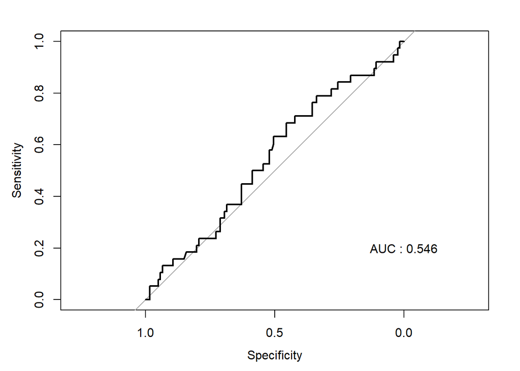

```r
plot(roc.rf.AIC)
auc.rf.AIC = paste("AUC :", round(auc(roc.rf.AIC),3))
text(0.0, 0.2, auc.rf.AIC)
```

## 4.3 Prédictions, ROC, AUC et Accuracy sur les variables issues de l’all

### 4.3.1 Naives Bayes

```r
mod.NB.all = naiveBayes(recurrent ~ ., data = train.clf.all)
pred.NB.all = predict(mod.NB.all, subset(test.clf.all, select = -recurrent))
cm.NB.all = confusionMatrix(as.factor(pred.NB.all), as.factor(test.clf.all$recurrent))
cm.NB.all$table
```

```
##           Reference
## Prediction FALSE TRUE
##      FALSE    25    7
##      TRUE      5    2
```

```r
acc.NB.all = cm.NB.all$overall[1]
acc.NB.all
```

```
##  Accuracy
## 0.6923077
```

Malgré une précision correcte sur le jeu de données test, la matrice de confusion nous informe que la majorité des erreurs de classification commises par l’algorithme sont dues à une mauvaise prédiction des cas de rechute (`reccurent`=TRUE). Seulement ce sont bien ces cas que l’on cherche à prédire de la meilleure manière possible.

### 4.3.2 Linear Discriminant Analysis

```r
mod.lda.all = lda(recurrent ~ ., data = train.clf.all)
pred.lda.all = predict(mod.lda.all, subset(test.clf.all, select = -recurrent))
cm.lda.all = confusionMatrix(as.factor(pred.lda.all$class), as.factor(test.clf.all$recurrent))
cm.lda.all$table
```

```
##           Reference
## Prediction FALSE TRUE
##      FALSE    26    8
##      TRUE      4    1
```

```r
acc.lda.all = cm.lda.all$overall[1]
acc.lda.all
```

```
##  Accuracy
## 0.6923077
```

Résultats similaires à la méthode précédente, même erreur de prédiction.

### 4.3.3 Quadratic Discriminant Analysis

```r
mod.qda.all = qda(recurrent ~ ., data=train.clf.all)
pred.qda.all = predict(mod.qda.all, subset(test.clf.all, select = -recurrent))
cm.qda.all = confusionMatrix(as.factor(pred.qda.all$class), as.factor(test.clf.all$recurrent))
cm.qda.all$table
```

```
##           Reference
## Prediction FALSE TRUE
##      FALSE    30    9
##      TRUE      0    0
```

```r
acc.qda.all = cm.qda.all$overall[1]
acc.qda.all
```

```
##  Accuracy
## 0.7692308
```

### 4.3.4. Support Vector Machine

```r
mod.svm.all <- svm(recurrent ~ ., data=train.clf.all, type="C")
pred.svm.all = predict(mod.svm.all, subset(test.clf.all, select = -recurrent))
cm.svm.all = confusionMatrix(as.factor(pred.svm.all), as.factor(test.clf.all$recurrent))
cm.svm.all$table
```

```
##           Reference
## Prediction FALSE TRUE
##      FALSE    30    9
##      TRUE      0    0
```

```r
acc.svm.all = cm.svm.all$overall[1]
acc.svm.all
```

```
##  Accuracy
## 0.7692308
```

Résultats encore moins bons.

## 4.3.5. kNN

```r
mod.knn.all = as.factor(knn(train=train.clf.all[-c(1)], test=test.clf.all[-c(1)], cl=train.clf.all$recurrent, k=5))
cm.knn.all = confusionMatrix(as.factor(mod.knn.all), as.factor(test.clf.all$recurrent))
cm.knn.all$table
```

```
##           Reference
## Prediction FALSE TRUE
##      FALSE    28    9
##      TRUE      2    0
```

```r
acc.knn.all = cm.knn.all$overall[1]
acc.knn.all
```

```
##  Accuracy
## 0.7179487
```

Résultats similaires.

## 4.3.6. Random Forest

```r
train.recurrent.all = as.factor(train.clf.all$recurrent)
test.recurrent.all = as.factor(test.clf.all$recurrent)
mod.rf.all = randomForest(train.clf.all[,-c(1)], train.recurrent.all)
pred.rf.all = predict(mod.rf.all, newdata=test.clf.all[,-c(1)], type="class")
cm.rf.all = confusionMatrix(pred.rf.all, as.factor(test.recurrent.all))
cm.rf.all$table
```

```
##           Reference
## Prediction FALSE TRUE
##      FALSE    30    9
##      TRUE      0    0
```

```r
acc.rf.all = cm.rf.all$overall[1]
acc.rf.all
```

```
##  Accuracy
## 0.7692308
```

```r
roc.rf.all = roc(train.clf.all$recurrent, mod.rf.all$votes[,2] )
```

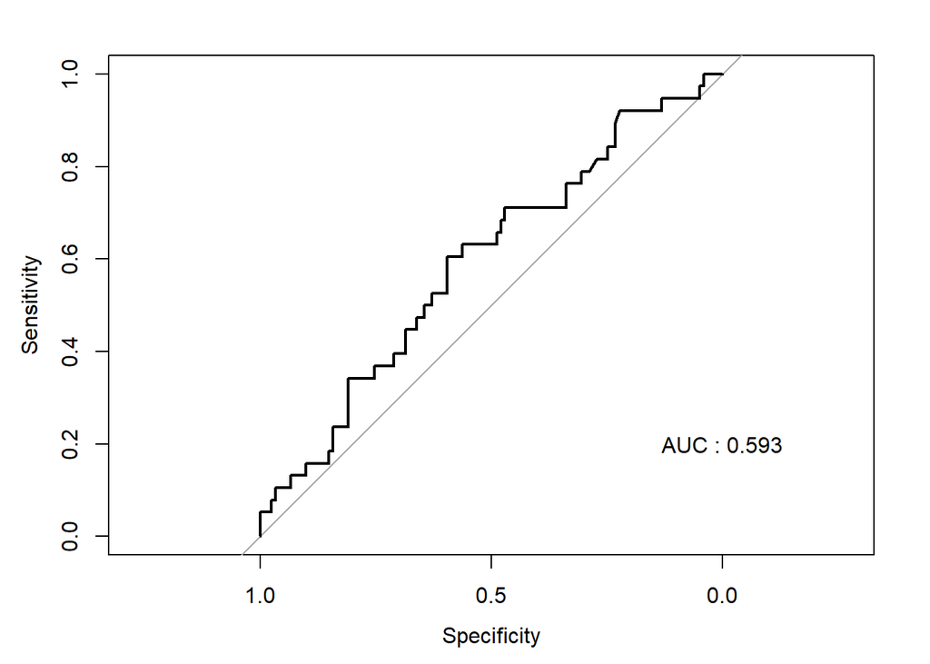

```r
plot(roc.rf.all)
auc.rf.all = paste("AUC :", round(auc(roc.rf.all),3))
text(0.0, 0.2, auc.rf.all)
```

# 5. Résumé des performances des modèles

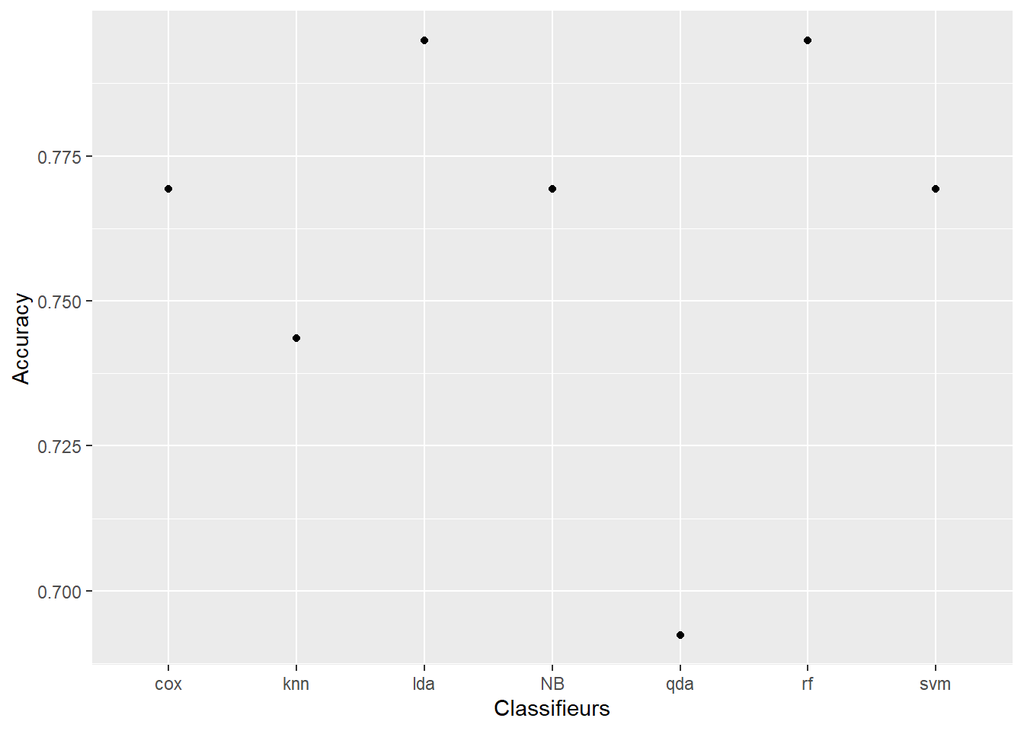

```r
clf = c("knn","lda","NB","qda","rf","svm","cox")
acc.AIC = c(acc.knn.AIC, acc.lda.AIC, acc.NB.AIC, acc.qda.AIC,
            acc.rf.AIC, acc.svm.AIC, acc.cox.AIC)
df.acc.AIC = data.frame(Classifieurs = clf, Accuracy = acc.AIC)
ggplot(df.acc.AIC, aes(x = Classifieurs,y = Accuracy)) + geom_point()
```

```r
#auc.AIC = c(auc.cox.AIC, auc.rf.AIC)
```

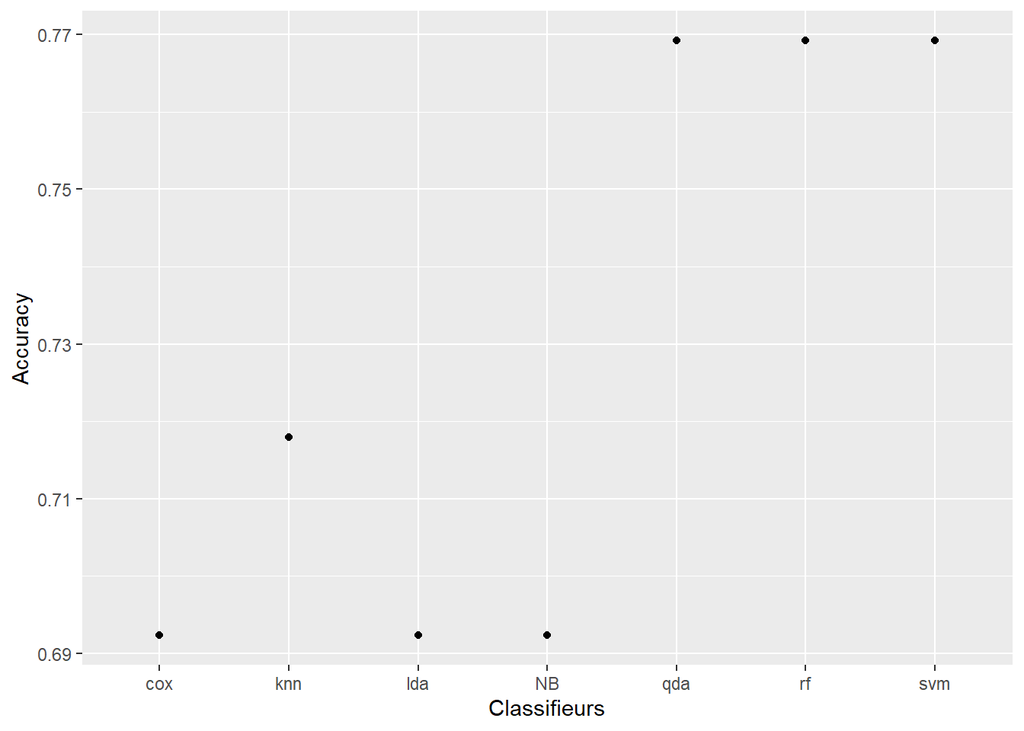

```r
acc.all = c(acc.knn.all, acc.lda.all, acc.NB.all, acc.qda.all,
            acc.rf.all, acc.svm.all,acc.cox.all)
df.acc.all = data.frame(Classifieurs = clf, Accuracy = acc.all)
ggplot(df.acc.all, aes(x = Classifieurs,y = Accuracy)) + geom_point()
```

```r
#auc.all = c(auc.cox.all, auc.rf.all)
```

# 6. Conclusion

Une manière de pallier le problème de classification serait d’équilibrer la répartition des classes dans les différents jeux de données. Seulement, nous ne disposons pas d’un nombre d’observations assez important pour réaliser cela.

De plus, on voit que tous les algorithmes utilisés sont sensibles à ce problème.